Skip to contents

# 🔍 数据质量、多样性与船队

Source: [`vignettes/articles/zh/quality-diversity-fleets.Rmd`](https://github.com/Linbojun99/faofishingreport/blob/main/vignettes/articles/zh/quality-diversity-fleets.Rmd)

```r
fao_settings(lang = "zh")   # 本文所有图表使用中文
```

📦 **数据来源**：[FAO全球捕捞产量](https://www.fao.org/fishery/collection/capture/en)（Global Capture Production）**2026.1.0**版（FAO于2026-03-30发布，1950–2024年），下载地址Capture_2026.1.0.zip，许可证[CC BY 4.0](https://creativecommons.org/licenses/by/4.0/)。用`fao_data_info()`查看你使用的版本和引用格式。

与📈 类群结构、资源状态与趋势中的分析一样，这些函数适用于任何产量数据：可以是`fishing_area_data()`得到的某个渔区，也可以是`load_fao_data()`的任意子集。图表保存在`figures/png/summary/`，表格保存在`tables/`，文件名以渔区名称（或`label`的值）开头；函数以不可见的方式返回结果。

```r
FAO27 <- fishing_area_data("Atlantic, Northeast")
```

## ⚙️ 通用参数

四个函数都有下面这些参数，后面各函数的参数表只列出它们自己的参数。

| 参数 | 含义 | 默认值 |
| --- | --- | --- |
| `area_data` | FAO产量数据：`fishing_area_data()$area_data`，或`load_fao_data()`的任意子集（如一个国家或几个渔区） | 必填 |
| `plot` | 是否把图保存到`figures/png/summary/` | `TRUE` |
| `table` | 是否把表格保存到`tables/` | `TRUE` |
| `lang` | 图中文字和名称的语言：`"en"`、`"zh"`或`"both"` | `NULL`：使用`fao_settings()`设定的语言（未修改时为`"en"`） |
| `pptx` | 是否同时把图保存为可编辑的PowerPoint文件，存放在`figures/pptx/summary/` | `FALSE`；`fao_settings(pptx = TRUE)`可对所有函数生效 |
| `plot_show` | 保存图表的同时把图画在绘图窗口中（例如RStudio的Plots窗格） | `FALSE`，或`fao_settings()`中的`plot_show` |
| `label` | 输出文件名开头的名称 | `NULL`：数据所属的渔区（或国家；含多个渔区和国家时为`"selected_data"`） |

## 🧪 数据质量

`data_quality()`展示统计数据在两个方面随时间的变化：

- **官方上报**的产量占比（FAO状态标记A）、由国家**估算**或由FAO插补的产量占比（标记E和I），以及带其他标记（如临时数据或可忽略的数值）的产量占比；
- 根据FAO的分类编码，**鉴定到种**、属、科，或只归到目及以上类群（如”Marine fishes nei”）的产量占比。

```r
quality <- data_quality(FAO27$area_data)
```

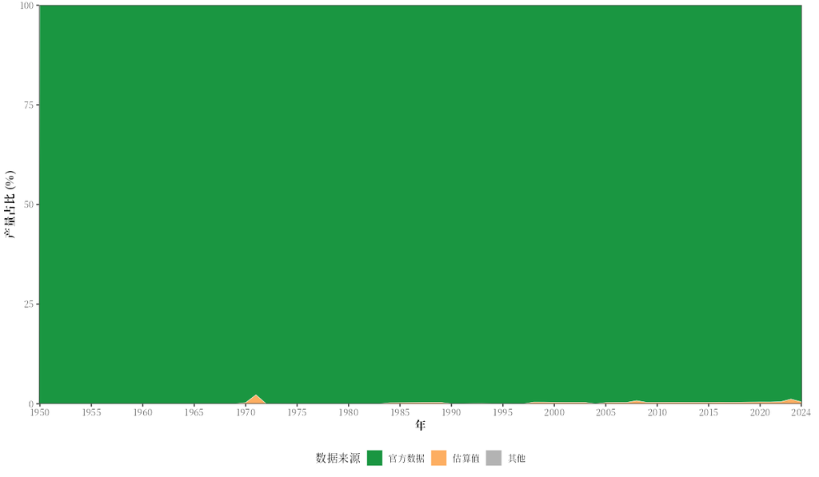

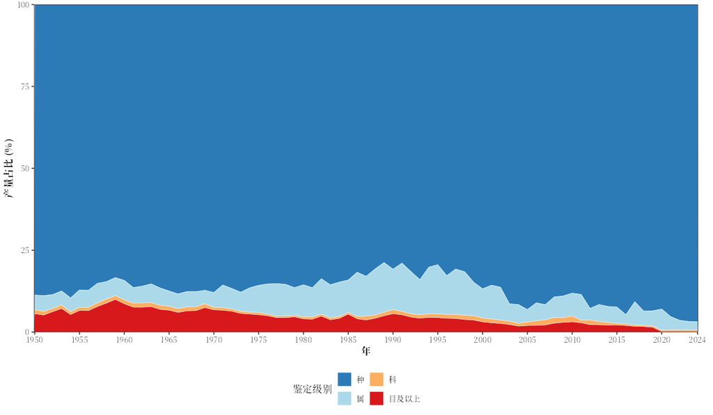

最近几年估算占比偏高，通常是因为FAO还没有收到各国的上报数据；这些数值往往会在下一版数据中修订（Garibaldi 2012）。国家表针对最近五年产量最大的几个国家，列出这几年其产量中有多少是估算的、有多少鉴定到种：

```r
show_table(quality$countries, digits = 1)
```

| country | country_en | catch_last_5_years | estimated_pct | species_level_pct |
| --- | --- | --- | --- | --- |
| 挪威 | Norway | 11327375 | 0.0 | 95.5 |
| 冰岛 | Iceland | 6329277 | 0.0 | 99.4 |
| 俄罗斯联邦 | Russian Federation | 4811200 | 0.0 | 99.6 |
| 大不列颠及北爱尔兰联合王国 | United Kingdom | 3340084 | 0.0 | 96.9 |
| 法罗群岛 | Faroe Islands | 3252896 | 0.0 | 98.1 |
| 丹麦 | Denmark | 2606338 | 0.0 | 79.8 |
| 法国 | France | 1824629 | 0.2 | 91.0 |
| 荷兰王国 | Netherlands (Kingdom of the) | 1327367 | 0.0 | 100.0 |
| 西班牙 | Spain | 1271825 | 0.0 | 94.4 |
| 爱尔兰 | Ireland | 1142570 | 16.4 | 85.8 |

| 参数 | 含义 | 默认值 |
| --- | --- | --- |
| `top_n` | 国家表中的国家数 | `10` |
| `area_data`、`plot`、`table`、`lang`、`pptx`、`label` | 见通用参数 |  |

输出：图`<label>_data_quality_status_share.png`和`<label>_data_quality_taxon_share.png`，表格`<label>_data_quality_status.csv`、`..._taxon.csv`和`..._countries.csv`；函数返回`data_status`、`taxon_level`（各类别的逐年产量）和`countries`。

FAO统计的是各国上报的产量（没有上报时由FAO估算）。产量重建研究加上了未报告产量和丢弃量的估计，发现全球海洋渔获量高于报告值，而且自峰值以来下降得更快（Pauly and Zeller 2016）。数据质量图反映的是统计数据是怎么得来的，而不是数据有多完整。

## 🌈 多样性与集中度

`diversity_concentration()`逐年计算以下指标：

| 指标 | 列名 | 计算方法 |
| --- | --- | --- |
| 上报的物种数 | `n_species` | 有产量且鉴定到种的条目数 |
| 国家数 | `n_countries` | 有产量的国家数 |
| 香农多样性指数（Shannon 1948） | `shannon_species` | $H = -\sum_i p_i \ln p_i$，其中$p_i$为物种条目$i$（所有条目，包括nei类群）在当年产量中的占比 |
| 物种/国家的HHI集中度（Rhoades 1993） | `hhi_species`、`hhi_countries` | $\text{HHI} = \sum_i (100\,p_i)^2$，取值0至10000 |
| 前N名占比 | `top5_species_pct`、`top5_countries_pct` | 产量最大的`top_n`个物种条目或国家所占的比例（%；列名随`top_n`变化） |

```r
diversity <- diversity_concentration(FAO27$area_data, top_n = 5)
```

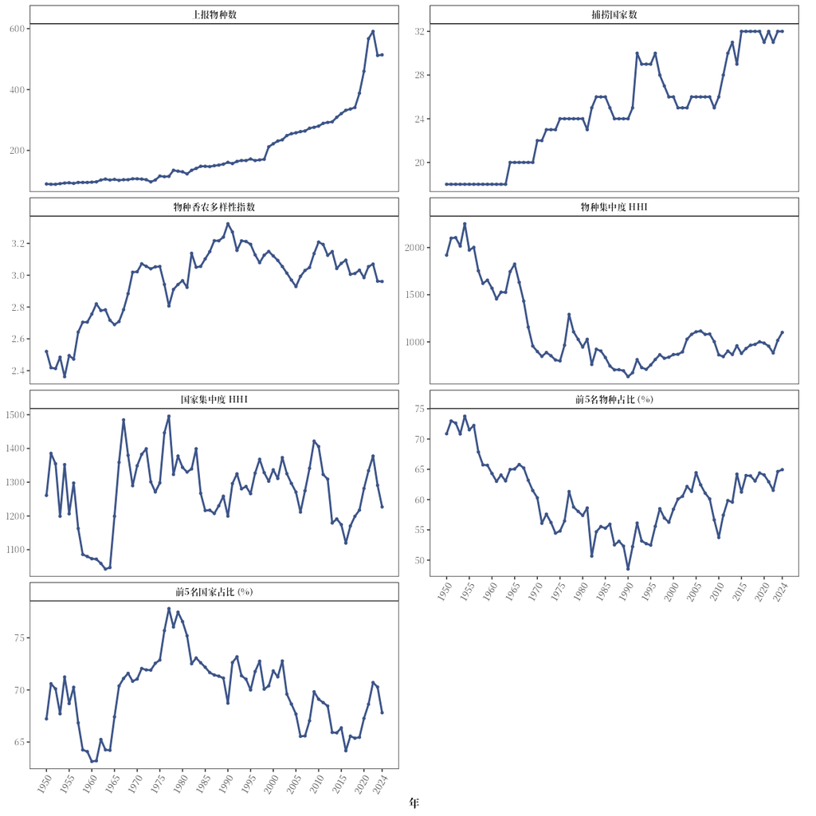

```r
show_table(subset(diversity, Year %in% c(1970, 1990, 2010, max(Year))), digits = 2)
```

|  | Year | n_species | n_countries | shannon_species | hhi_species | hhi_countries | top5_species_pct | top5_countries_pct |
| --- | --- | --- | --- | --- | --- | --- | --- | --- |
| 1970 | 1970 | 107 | 22 | 3.02 | 897.68 | 1,348.67 | 60.29 | 71.05 |
| 1990 | 1990 | 161 | 24 | 3.32 | 631.00 | 1,199.47 | 48.53 | 68.73 |
| 2010 | 2010 | 280 | 26 | 3.21 | 862.25 | 1,405.73 | 53.74 | 69.11 |
| 2024 | 2024 | 514 | 32 | 2.96 | 1,100.44 | 1,226.80 | 64.95 | 67.81 |

| 参数 | 含义 | 默认值 |
| --- | --- | --- |
| `top_n` | 计算前N名占比时取的物种条目数和国家数 | `5` |
| `area_data`、`plot`、`table`、`lang`、`pptx`、`label` | 见通用参数 |  |

输出：图`<label>_diversity.png`（全部指标）和表格`<label>_diversity.csv`；函数返回一个数据框，每年一行。

**指标解读**：香农多样性指数越高，说明物种条目越多、各条目的产量越均匀；有$S$个条目时，其最大值为$\ln S$。按照美国的企业并购指南（U.S. Department of Justice and Federal Trade Commission 2010），HHI低于1500为不集中，1500至2500为中度集中，高于2500为高度集中。例如，三个物种的占比分别为50%、30%和20%，则$H = 1.03$，$\text{HHI} = 50^2 + 30^2 + 20^2 = 3800$。

这些指标基于FAO的物种条目，其中包括未分类（nei）类群。当FAO把某个未分类（nei）类群拆分为具体物种时，即使海里什么都没有改变，香农多样性指数也会上升，HHI集中度也会下降。国家拆分时国家指标同样会变化，例如1991年的苏联。

## 🏳️ 国家分组

`country_group_summary()`依据FAO国家列表，按国家分组汇总产量：**世界银行收入分组**、**大洲**或**地区**。它保存各分组产量图和占比图，以及与`species_group_composition()`相同格式的按年代汇总表。

```r
income <- country_group_summary(FAO27$area_data, group = "income")
```

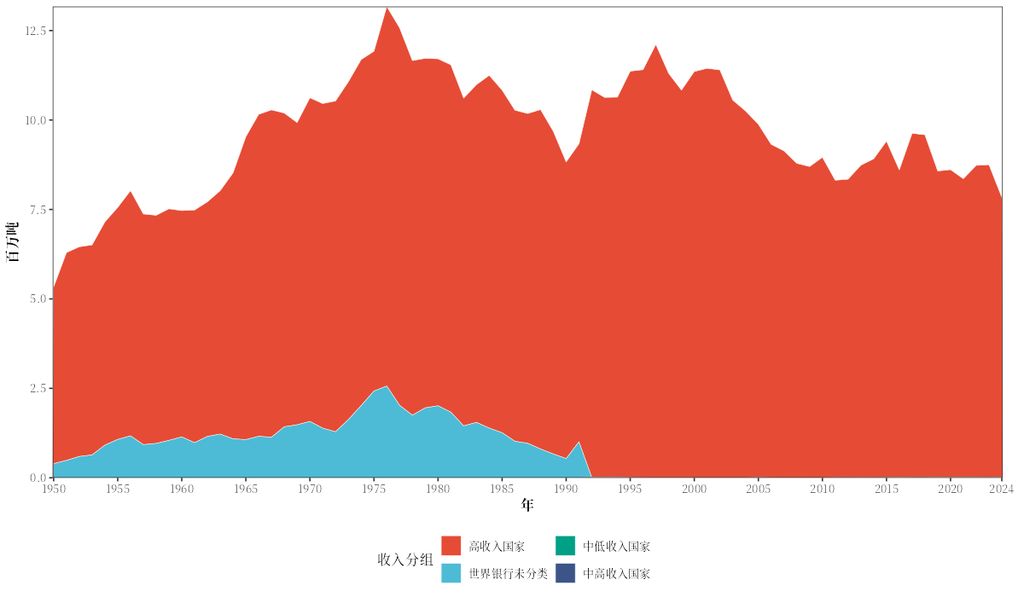

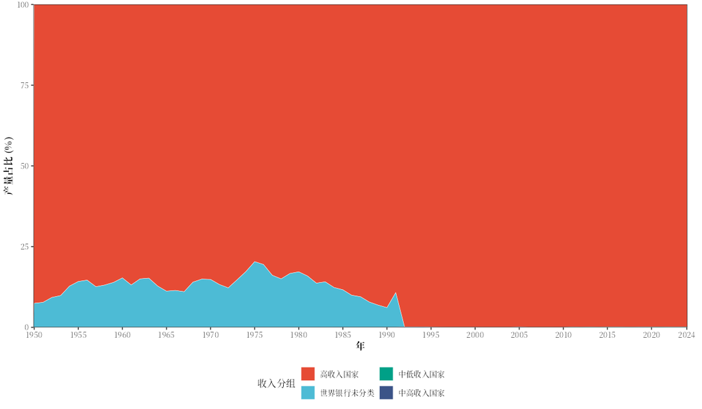

```r
country_group_summary(FAO27$area_data, group = "region", top_n = 6, lang = "zh")
```

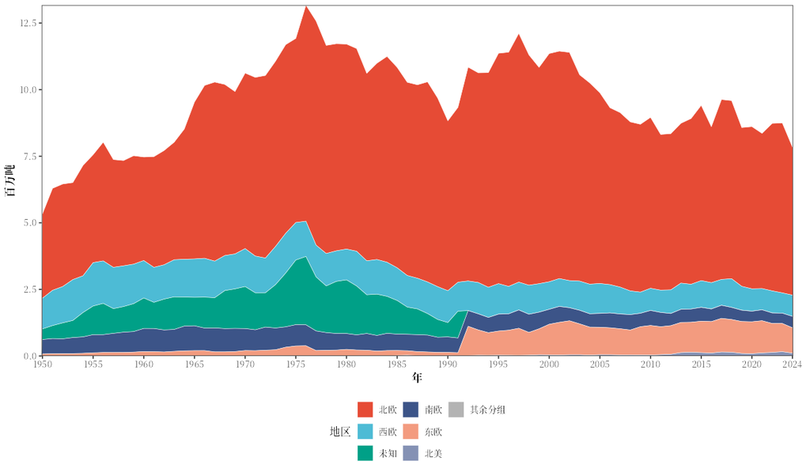

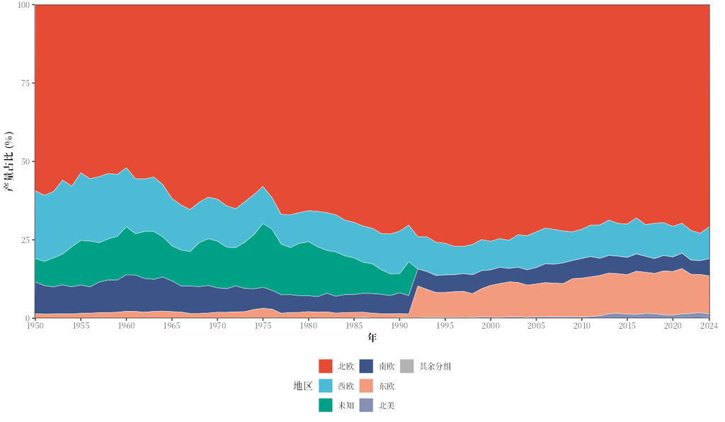

| 参数 | 含义 | 默认值 |
| --- | --- | --- |
| `group` | `"income"`（世界银行收入分组）、`"continent"`（大洲）或`"region"`（地区） | `"income"` |
| `top_n` | 单独显示的分组数，其余合并 | `8` |
| `area_data`、`plot`、`table`、`lang`、`pptx`、`label` | 见通用参数 |  |

输出：图`<label>_country_income.png`（或`_continent`、`_region`）和`..._share.png`，表格`<label>_country_income.csv`；函数返回`yearly`和`table`。

## 🚢 沿岸国与远洋捕捞国

`coastal_distant()`把产量分为与该渔区**接壤**的沿岸国和来自其他地区的**远洋**捕捞船队两部分，并列出主要的远洋捕捞国。

若一个国家的陆地（包括海外领土，取自Natural Earth的地图单元）位于FAO渔区边界（CWP手册中的FAO主要渔区）20 km以内，即视为该渔区的沿岸国。苏联等已不存在的国家采用其继承国的海岸线。例如在34区（中东大西洋），西班牙和葡萄牙分别因加那利群岛和马德拉群岛而被算作沿岸国。以”Other nei”上报的产量显示为“未知”。

```r
fleets <- coastal_distant(FAO27$area_data)
```

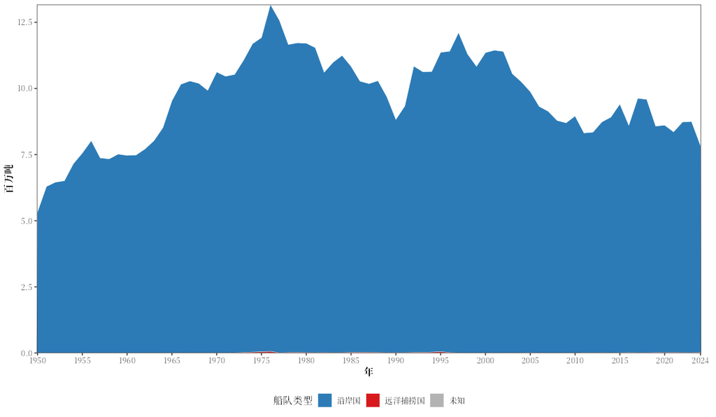

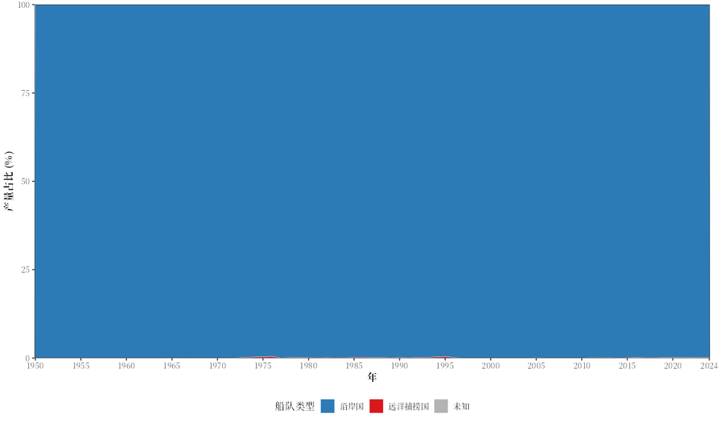

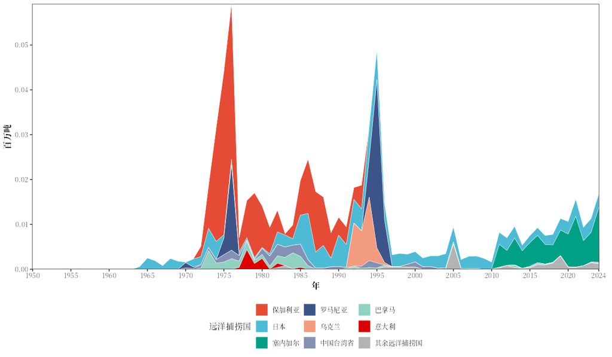

```r
show_table(fleets$table, digits = 0)
```

| 船队类型 | 1950s | 1960s | 1970s | 1980s | 1990s | 2000s | 2010s | 2020s | 2020 | 2021 | 2022 | 2023 | 2024 | share_2024_pct |
| --- | --- | --- | --- | --- | --- | --- | --- | --- | --- | --- | --- | --- | --- | --- |
| 沿岸国 | 6,956,166 | 8,930,049 | 11,522,278 | 10,722,687 | 10,713,646 | 10,080,097 | 8,899,457 | 8,445,147 | 8,598,826 | 8,343,100 | 8,719,874 | 8,738,529 | 7,825,406 | 100 |
| 远洋捕捞国 | 0 | 1,000 | 20,186 | 14,021 | 16,346 | 3,569 | 7,511 | 12,742 | 10,649 | 15,624 | 9,353 | 11,298 | 16,787 | 0 |
| 未知 | 0 | 0 | 0 | 2 | 107 | 0 | 1,144 | 930 | 2,227 | 2 | 2,420 | 2 | 2 | 0 |

| 参数 | 含义 | 默认值 |
| --- | --- | --- |
| `top_n` | 单独显示的远洋捕捞国数量 | `8` |
| `area_data`、`plot`、`table`、`lang`、`pptx`、`label` | 见通用参数 |  |

该分析只适用于海洋渔区；数据中的内陆渔区会被剔除，并给出提示信息。输出：图`<label>_coastal_distant.png`和`..._share.png`（沿岸国、远洋捕捞国和未知部分的产量）、`<label>_coastal_distant_countries.png`（主要远洋捕捞国），表格`<label>_coastal_distant.csv`和`..._countries.csv`；函数返回`yearly`、`distant`和`table`。主要远洋捕捞国的概况见🔬 渔获骤变、渔业崩溃、同步性与远洋捕捞。

## 📝 写入Word报告

`fao_report()`会把数据质量、多样性与集中度、沿岸国与远洋捕捞国写进某个渔区的Word报告（见📝 一键生成评估报告（Word、LaTeX、PDF））：它们是报告的`quality`、`diversity`和`fleets`三个章节，默认都会写入。各函数的设置以章节名为前缀传入（`data_quality()`用`quality_`，`diversity_concentration()`用`diversity_`，`coastal_distant()`用`fleets_`），设为`FALSE`即可去掉某个章节：

```r
fao_report(27, diversity_top_n = 3, fleets = FALSE)
```

`country_group_summary()`不在报告中。

## 📖 参考文献

CWP (Coordinating Working Party on Fishery Statistics). *CWP Handbook of Fishery Statistics*: Main water areas (FAO major fishing areas). Rome: FAO. https://www.fao.org/cwp-on-fishery-statistics/handbook/general-concepts/main-water-areas/en/

FAO (2026). *Global Capture Production 1950–2024*, release 2026.1.0. In: Fisheries and Aquaculture. Rome: FAO. https://www.fao.org/fishery/collection/capture/en. Licence: CC BY 4.0. Release file: https://www.fao.org/fishery/static/Data/Capture_2026.1.0.zip

Garibaldi, L. (2012). The FAO global capture production database: a six-decade effort to catch the trend. *Marine Policy* 36: 760–768. [doi:10.1016/j.marpol.2011.10.024](https://doi.org/10.1016/j.marpol.2011.10.024)

Natural Earth. Free vector and raster map data at 1:10m, 1:50m and 1:110m scales. https://www.naturalearthdata.com/

Pauly, D. and Zeller, D. (2016). Catch reconstructions reveal that global marine fisheries catches are higher than reported and declining. *Nature Communications* 7: 10244. [doi:10.1038/ncomms10244](https://doi.org/10.1038/ncomms10244)

Rhoades, S.A. (1993). The Herfindahl-Hirschman index. *Federal Reserve Bulletin* 79(3): 188–189.

Shannon, C.E. (1948). A mathematical theory of communication. *Bell System Technical Journal* 27: 379–423. [doi:10.1002/j.1538-7305.1948.tb01338.x](https://doi.org/10.1002/j.1538-7305.1948.tb01338.x)

U.S. Department of Justice and Federal Trade Commission (2010). *Horizontal Merger Guidelines*, section 5.3 (market concentration). Washington, DC. https://www.justice.gov/atr/horizontal-merger-guidelines-08192010